# Global GDP per capita Analysis

Dongbing Han

# Introduction

Gross domestic product per capita (GDP per capita), a refelction of differences in the cost of living and the inflation rates, is an important index for analyzing the well-being of people in a country. Through the analysis of GDP per capita, we can discover and understand the current economic situation, discover new economic growth force, and find where should be improved. This R-Studio project is try to analysis the factors that affect GDP per capita across world. By collecting the data of GDP per capita world wide as well as factors afftected GDP per capita, I want to find the relationship between each factor and GDP per capita.

# Data

A description of the data:

# Introduction

The data set I use is from the Quality of Government Institute (QoG), an independent research institute within the Department of Political Science at the University of Gothenburg. The institute conducts this complete research on the causes, consequences, and the nature of factors that affects the economic well-being of each country. The factors which affect GDP per capita and displayed in QoG report mainly relevent to the Quality of Government, Population, Labor market, Education and stability. In this R-Studio report, in order to privide a representative and complete project, I select twelve factors which I think are important in the analysis of GDP per capita. The factor I choose are mainly relevent to the five perspective I mentioned above. The purpose of analysis of these factors is trying to find the relationship between each factor and the GDP per capita and to analyze how each factor affect GDP per capita.

# Variable

| Variable | Description |
| --- | --- |
| income | the Gross Domestic Product per capita (Maddison Project Database 2018) |
| urban_pop | the Urban population(% total population) |
| rural_pop | the Rural population(% total population) |
| gov_effiency | the Government Effectiveness Estimate |
| fair_elections | Free and Fair Elections |
| unemployment | Unemployment,total(% of labor force) |
| employ_service | Employment in service(% total employment) |
| employ_industry | Employment in industry(% total employment) |
| employ_agriculture | Employment in agriculture(% total employment) |
| currency_stability | Currency and Price Stability |
| policy_stability | Political Stability and Absence of Violence/Terrorism, Estimate |
| edu_spend | Government expenditure on education(% GDP) |
| human_capital | Human Capital Index |

**Summary statistics**

| Statistic | N | Mean | St. Dev. | Min | Pctl(25) | Pctl(75) | Max |
| --- | --- | --- | --- | --- | --- | --- | --- |
| income | 163 | 17,953.990 | 19,316.580 | 605.000 | 3,623.500 | 25,294.500 | 139,542.000 |
| urban_pop | 192 | 57.664 | 23.309 | 12.078 | 38.641 | 77.186 | 100.000 |
| rural_pop | 192 | 42.336 | 23.309 | 0.000 | 22.814 | 61.359 | 87.922 |
| fair_elections | 128 | 5.836 | 2.805 | 1.000 | 3.000 | 8.000 | 10.000 |
| gov_effiency | 192 | -0.074 | 0.995 | -2.197 | -0.747 | 0.500 | 2.237 |
| unemployment | 177 | 7.869 | 5.959 | 0.160 | 3.980 | 10.025 | 27.694 |
| employ_service | 177 | 52.236 | 20.239 | 6.065 | 39.163 | 68.540 | 86.432 |
| employ_industry | 177 | 19.898 | 9.121 | 2.373 | 13.808 | 25.073 | 54.141 |
| employ_agriculture | 177 | 27.866 | 24.998 | 0.198 | 6.099 | 42.528 | 91.561 |
| currency_stability | 128 | 6.703 | 1.981 | 1.000 | 5.875 | 8.000 | 10.000 |
| policy_stability | 194 | -0.072 | 0.978 | -2.974 | -0.635 | 0.760 | 1.525 |
| edu_spend | 138 | 4.640 | 1.723 | 1.371 | 3.403 | 5.594 | 12.460 |
| human_capital | 142 | 2.590 | 0.693 | 1.193 | 1.987 | 3.146 | 3.734 |

# Data analysis

## Overview

The fellowing part is to find the relationship between each factor and GDP per capita. The variable I choose above are divided in to five parts including population, government, labor force, stability, education and human capital.

# Population analysis

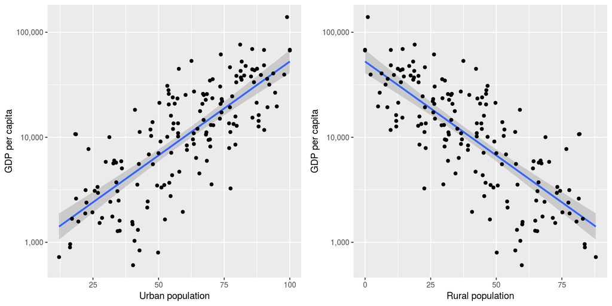

Variable explanation:

Urban population refers to people living in urban areas as defined by national statistical offices. Rural population refers to people living in rural areas as defined by national statistical offices. Rural population calculated as the difference between total population and urban population.

Figure analysis:

Chart one refect the relationship between GDP per capita and the percentage of urban population in total population. Chart two refect the relationship between GDP per capita and the percentage of rural population in total population. From the chart one, which the regression line is a direct positive proportional relationship, it is easy for us to conclude that the higher percentage of urban population can lead to relatively higer income (GDP per capita). In the contrast, the chart two, which the income and rural population form a negative proportional relationship, indicates that the higer percentage of rural population will relatively reduce the income (GDP per capita).

# Government Evaluation

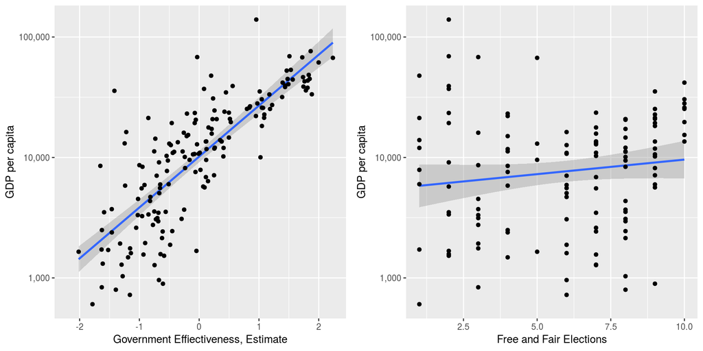

Variable explanation:

The evaluation of Government Effectiveness combines the evaluation of the quality of public service provision, the quality of the bureaucracy, the competence of civil servants, the independence of the civil service from political pressures, and the credibility of the government’s commitment to policies.

The purpose of Free and Fair Elections is evaluating to what extend are political representatives determined by general. This evaluation mainly contains fellowing four level, from lowest to highest:

1. There are no elections at the national level.
2. General elections are held, but serious irregularities during voting process and ballot count occur. The rights to vote, campaign and run for office are restricted, and elections have de facto only limited influence over who governs.
3. General, multi-party elections are held, conducted properly and accepted as the means of filling political posts. However, there are some constraints on the fairness of the elections with regard to registration, campaigning or media access.
4. There are no constraints on free and fair elections.

Figure analysis:

From the figure 1, since GDP per capita and Government Effectiveness form a positive proportional relationship, it is reasonable to conclude that the government’s work efficiency, the quality of service provided to citizens and the credibility of the government have a crucial impact on income (GDP per capita). On the contrary, in Figure 2, since there is no obvious relationship between Fair and Free Election and income (GDP per capita), and points are irregularly scattered on both sides of the regression line, it is possible to conclude that Free and Fair Election only has minimal or none influence on income (GDP per capita) or Free and Fair Election are not the main factor affecting GDP per capita.

# Labor Market analysis

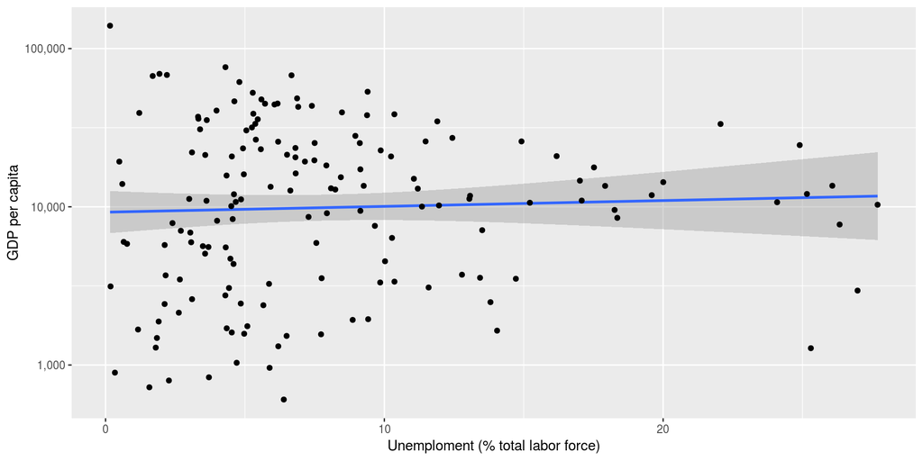

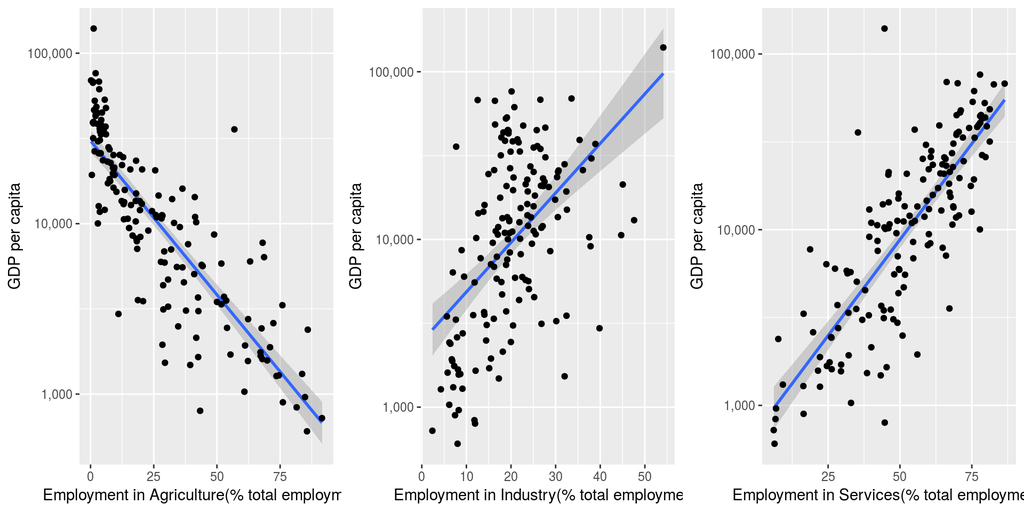

Variable explanation:

Employment is defined as persons in working age who were engaged in any activity to produce goods or provide services for pay or profit or not at work due to temporary absence from a job. Thus, an important criterion for measuring DGP per capita is to analyze the country’s employment rate (or unemployment rate) and the situation of industry including fellowing three main categories:

1.The agriculture sector consists of activities in agriculture, hunting, forestry and fishing.

2.The industry sector consists of mining and quarrying, manufacturing, construction, and public utilities (electricity, gas, and water).

3.The services sector consists of wholesale and retail trade and restaurants and hotels; transport, storage, and communications; financing, insurance, real estate, and business services; and community, social, and personal services.

Figure analysis:

The first figure has a certain degree of difference from my ideal expectations. What I think the trend of this graph should be that as the unempolment rate continues to increase, income (GDP per capita) should show a rapid decline. However, from figure 1, I cannot find this relationship that I expected. On the contrary, the figure shows that the effect of unempolment rate on income (GDP per capita) is very small. Even for the increase of the unempolment rate, income (GDP per capita) has an unconspicuous upward increasing trend.

The second, third and fourth figures above basically conform to my psychological expectations. From the negative proportional relationship in Figure 2, income (GDP per capita) shows a downward trend with the increase of the agricultural employment rate. This is means that the agriculture industry is not productive enough. From the positive proportional relationship in Figure 3 and Figure 4, income (GDP per capita) shows an upward increasing trend as the employment rate of industry and services increases. After that, more important task for me to do is to specifically analyze the proportional and numerical relationship between industry and service industry and income (GDP per capita). Or equvialently, I need find which factor has more significant and bigger influence on GDP per capita.

# Stability

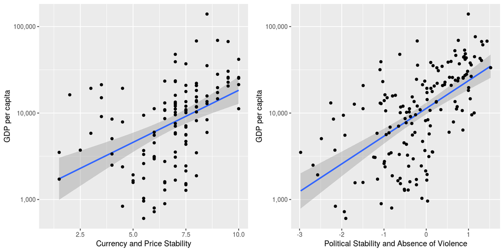

Variable explanation:

I have always believed that the economic development of a country and the growth of GDP per capita cannot be separated from the stability of government, society, finance, and prices. In order to prove my guess, I chose these two variables. Currency and Price Stability indicates the extent that institutional or political precautions to control inflation sustainably, appropriate monetary policies and fiscal policies. The political stability and absence of violence can represent how stable the whole society is.

Figure analysis:

As I suspected, from the two positive proportional relationships above, stability has a great influence on income (GDP per capita). With the increase of currency and price stability and political stability, income (GDP per capita) also has a clear upward increasing trend. After this, it seems reasonable to analyze from a specific and numerical perspective to discover which factor has a greater impact on income (GDP per capita).

# Education and Human Capital

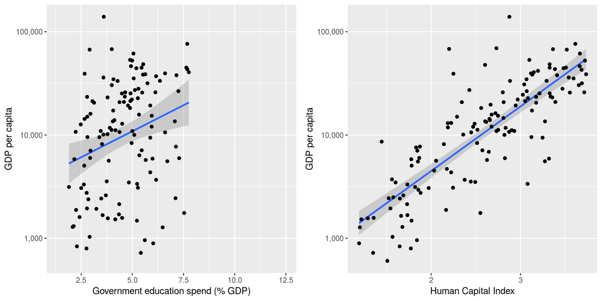

Variable explanation:

General government expenditure on education (current, capital, and transfers) is expressed as a percentage of GDP. It includes expenditure funded by transfers from international sources to government. General government usually refers to local, regional and central governments. And Human capital index is evaluated by years of schooling and assumed returns.

## In-depth analysis

From all the chart above, it is clearly shows that urban population, rural population, government effiency, employment in agriculture(% total employment), employment in industry(% total employment), employment in service(% total employment), currency and price stability, political stability and absence of violence, government expenditure on education(% GDP) and Human Capital Index have relationshipe with GDP per capita, but Free and Fair Elections and Unemployment,total(% of labor force) do not show this kind of relationship. In this part, the purpose of In-depth analysis is to find the qulitative or numerical effects of each factor on GDP per capita.

**Regression results**

|  | *Dependent variable:* |  |  |  |  |  |  |  |  |
| --- | --- | --- | --- | --- | --- | --- | --- | --- | --- |
|  | log(income) |  |  |  |  |  |  |  |  |
|  | (1) | (2) | (3) | (4) | (5) | (6) | (7) | (8) | (9) |
| urban_pop | 0.041*** |  |  |  |  |  |  |  |  |
|  | (0.003) |  |  |  |  |  |  |  |  |
| rural_pop |  | -0.041*** |  |  |  |  |  |  |  |
|  |  | (0.003) |  |  |  |  |  |  |  |
| employ_agriculture |  |  | -0.042*** |  |  |  |  |  |  |
|  |  |  | (0.002) |  |  |  |  |  |  |
| employ_industry |  |  |  | 0.068*** |  |  |  |  |  |
|  |  |  |  | (0.009) |  |  |  |  |  |
| employ_service |  |  |  |  | 0.050*** |  |  |  |  |
|  |  |  |  |  | (0.003) |  |  |  |  |
| currency_stability |  |  |  |  |  | 0.277*** |  |  |  |
|  |  |  |  |  |  | (0.050) |  |  |  |
| policy_stability |  |  |  |  |  |  | 0.738*** |  |  |
|  |  |  |  |  |  |  | (0.081) |  |  |
| edu_spend |  |  |  |  |  |  |  | 0.232*** |  |
|  |  |  |  |  |  |  |  | (0.073) |  |
| human_capital |  |  |  |  |  |  |  |  | 1.438*** |
|  |  |  |  |  |  |  |  |  | (0.087) |
| Constant | 6.755*** | 10.872*** | 10.330*** | 7.810*** | 6.566*** | 7.045*** | 9.333*** | 8.136*** | 5.533*** |
|  | (0.177) | (0.128) | (0.076) | (0.200) | (0.159) | (0.354) | (0.078) | (0.352) | (0.233) |
| Observations | 161 | 161 | 159 | 159 | 159 | 123 | 163 | 123 | 138 |
| R<sup>2</sup> | 0.579 | 0.579 | 0.716 | 0.269 | 0.666 | 0.202 | 0.342 | 0.077 | 0.667 |
| Adjusted R<sup>2</sup> | 0.576 | 0.576 | 0.714 | 0.264 | 0.664 | 0.196 | 0.338 | 0.069 | 0.665 |
| Residual Std. Error | 0.779 (df = 159) | 0.779 (df = 159) | 0.643 (df = 157) | 1.030 (df = 157) | 0.696 (df = 157) | 1.014 (df = 121) | 0.978 (df = 161) | 1.202 (df = 121) | 0.712 (df = 136) |
| F Statistic | 218.401*** (df = 1; 159) | 218.401*** (df = 1; 159) | 395.227*** (df = 1; 157) | 57.808*** (df = 1; 157) | 313.249*** (df = 1; 157) | 30.722*** (df = 1; 121) | 83.668*** (df = 1; 161) | 10.058*** (df = 1; 121) | 272.379*** (df = 1; 136) |
| *Note:* | p<0.1; p<0.05; p<0.01 |  |  |  |  |  |  |  |  |

# Discussion and conclusion

From this chart we can clearly see the specific and accurate numerical proportional relationship between each factor and the increase rate of income (GDP per capita).

For example, from the coefficient I know that for every increase 1% in urban population, income grows by 4.1% and rural population increases by 1%, income decreases by 4.1%. Because what explained in the figure analysis that the definition of rural population is the difference between total population and urban population. Thus, it seems reasonable that the coeffcient of rural population and urban population is the same.

Moreover, from the coefficient I know that for every increase 1% in employment in agriculture（% total employment), income decreases by 4.2%; and employment in industry (% total employment) increases by 1%, income increases by 6.8%; and employment in service industry (% total employment) increase by 1%, the income increases 5%. Because the coeffcient of employment in industry is relative higer than that of agriculture and service factor, it shows that the effects of employment in industry have bigger influence on income compared to that of services and agriculture factors. And the negative cofficient explains that the agriculture is not productive enough.

Thirdly, from the coefficient I know that for every increase a unit in currency stability, income increases by 27.7%; and policy stability increases by a unit, income increases by 73.8%. The large cofficient shows that the stability of a country has huge effects on GDP per capita.

Finally, from the coefficient I know that for every increase 1% in government education expending, income inceases by 23.2%; and Human Capital Index increases by a unit, income increases by 143.8%. Because the coeffcient of Human Capital Index is relative higer than that of government education expenditure, it shows that the effects of Human Capital Index on income is relavtively higer than that of government education expenditure. Also, since the coefficient of Human Capita Index is strange, maybe I should evaluate the relationship between government education expediture and Human Capital Index towards income (GDP per capita) by separating these two factors in the next figure.

# Further analysis of Government Education Expenditure and Human Capital

**Regression results**

|  | *Dependent variable:* |  |
| --- | --- | --- |
|  | log(income) |  |
|  | (1) | (2) |
| urban_pop | 0.027*** | 0.036*** |
|  | (0.003) | (0.004) |
| policy_stability | 0.098 | 0.412*** |
|  | (0.086) | (0.101) |
| currency_stability | 0.030 | 0.025 |
|  | (0.044) | (0.053) |
| human_capital | 0.733*** |  |
|  | (0.111) |  |
| edu_spend |  | -0.088* |
|  |  | (0.052) |
| Constant | 5.477*** | 7.317*** |
|  | (0.380) | (0.421) |
| Observations | 106 | 89 |
| R<sup>2</sup> | 0.768 | 0.693 |
| Adjusted R<sup>2</sup> | 0.759 | 0.679 |
| Residual Std. Error | 0.564 (df = 101) | 0.658 (df = 84) |
| F Statistic | 83.504*** (df = 4; 101) | 47.501*** (df = 4; 84) |
| *Note:* | p<0.1; p<0.05; p<0.01 |  |

# Discussion and conclusion

From this chart, what we can find is the strange difference in coefficient in this chart and the coefficient in the chart above. The coefficient of human capital and government education expenditure in above chart is 1.438 and 0.232 separately. But, the coefficient of human capital and government education expenditure in this chart is only 0.733 and -0.088 separately. The difference between the data in this two chart shows that the government education expenditure itself might not have obvious relationship between income (GDP per capita). It also shows that for some of country, it do not have ability to transfer the education spending to the increase of GDP per capita or have no ability to transfer the education spednding to human capital. What is more surprising is that in the second chart, it shows that the increase of government education expenditure even might have negative effect on GDP per capita because it shows a negative coefficient (-0.088). What I suppose is the human capital have direct and obvious relationship with GDP per capita. And the government education expenditure when only can transform into human capital, it can affect the income (GDP per capita).

# Citations

Bolt, J., Inklaar, R., de Jong, H., & van Zanden, J. L. (2018). Maddison project database, version 2018. Retrieved from https://www.rug.nl/ggdc/historicaldevelopment/maddison/research (Rebasing Maddison: new income comparisons and the shape of long-run economic development)

World Bank. (2016). World development indicators. The World Bank Washington DC.

Bertelsmann Stiftung. (2018). Transformation index of the bertelsmann stiftung 2018. Bertelsmann Stiftung. Retrieved from http://www.bti-project.org/en/index/overview

Kaufmann, D., Kraay, A., & Mastruzzi, M. (2010). The worldwide governance indicators: a summary of methodology, data and analytical issues. World Bank Policy Research Working Paper, 5430.

Feenstra, R. C., Inklaar, R., & Timmer, M. P. (2015). The next generation of the penn world table. The American Economic Review, 105(10), 3150–3182. Retrieved from www.ggdc.net/pwt